# Count / Rate Outcomes in ForestSearch

Full Pipeline: GRF Screening, Subgroup Search, Bootstrap, Cross-Validation, and Visualization

Author

Larry F. Leon

Published

March 27, 2026

# 1 Introduction

ForestSearch v0.2.0 extends the full subgroup identification pipeline to **count / rate outcomes** via Poisson GLMs with optional overdispersion correction. This document exercises every stage of the pipeline on synthetic clinical trial data with a known heterogeneous treatment effect:

| Stage | Function | Purpose |
| --- | --- | --- |
| GRF screening | `grf.subg.harm.glm()` | Candidate factor selection |
| Subgroup search | `forestsearch()` with `outcome_type = "count"` | Integrated pipeline |
| Summary tables | `sg_tables()` | Per-subgroup estimates |
| Outcome plots | `plot_sg_glm_outcomes()` | Bar chart with effect annotations |
| Per-subgroup GLM | `create_glm_row()` | Point estimate + CI |
| Biomarker profile | `glm_effect_profile()` | Smooth treatment-effect curve |
| Forest plot | `gg_forest()` | Publication-quality CI plot |
| Bootstrap | `forestsearch_bootstrap_dofuture()` | Bias correction |
| Cross-validation | `forestsearch_Kfold()` | Replication stability |

# 2 Setup

```r
library(forestsearch)
library(ggplot2)
library(patchwork)
library(gt)
library(data.table)
```

```r
timings <- list()
t_vignette_start <- proc.time()
```

# 3 Synthetic Data

The DGM plants a **harm subgroup** (`v1 = 1`, prevalence 35 percent) where treatment *increases* the event rate (true IRR $\approx$ 2.0), while the complement benefits (true IRR $\approx$ 0.67). A continuous biomarker adds a smooth interaction on top.

```r
set.seed(sim_seed)
n <- sim_n

df <- data.frame(
  id          = seq_len(n),
  treat       = rbinom(n, 1, 0.5),
  v1          = as.factor(rbinom(n, 1, 0.35)),
  v2          = as.factor(rbinom(n, 1, 0.50)),
  v3          = as.factor(rbinom(n, 1, 0.45)),
  age         = round(rnorm(n, 60, 12)),
  biomarker   = round(runif(n, 0.5, 5.0), 2),
  person_time = round(runif(n, 0.5, 3.0), 2)
)

# Poisson outcome with heterogeneous treatment effect
log_rate <- with(df, {
  -1.2 +
    0.7  * treat * (v1 == 1) +
    -0.4 * treat * (v1 == 0) +
    0.15 * treat * (biomarker - 2.5) +
    0.02 * (age - 60) +
    log(person_time)
})
df$events <- rpois(n, lambda = exp(log_rate))
```

```r
cat("=== Data Summary ===\n")
```

```
#> === Data Summary ===
```

```r
cat("N:", n, "\n")
```

```
#> N: 800
```

```r
cat("Events: mean =", round(mean(df$events), 2),
    ", range = [", min(df$events), ",", max(df$events), "]\n")
```

```
#> Events: mean = 0.58 , range = [ 0 , 6 ]
```

```r
cat("Zero counts:", sum(df$events == 0),
    sprintf("(%.1f%%)\n", 100 * mean(df$events == 0)))
```

```
#> Zero counts: 462 (57.8%)
```

```r
cat("Person-time: mean =", round(mean(df$person_time), 2), "years\n\n")
```

```
#> Person-time: mean = 1.71 years
```

```r
cat("Per-arm summary:\n")
```

```
#> Per-arm summary:
```

```r
for (arm in 0:1) {
  idx <- df$treat == arm
  rate <- sum(df$events[idx]) / sum(df$person_time[idx])
  cat(sprintf("  treat = %d: n = %d, events = %d, PT = %.1f, rate = %.3f/yr\n",
              arm, sum(idx), sum(df$events[idx]),
              sum(df$person_time[idx]), rate))
}
```

```
#>   treat = 0: n = 419, events = 225, PT = 718.5, rate = 0.313/yr
#>   treat = 1: n = 381, events = 239, PT = 649.8, rate = 0.368/yr
```

```r
fit_overall <- glm(events ~ treat + offset(log(person_time)),
                   family = poisson, data = df)
fit_v1_1 <- glm(events ~ treat + offset(log(person_time)),
                family = poisson, data = df[df$v1 == 1, ])
fit_v1_0 <- glm(events ~ treat + offset(log(person_time)),
                family = poisson, data = df[df$v1 == 0, ])

truth_df <- data.frame(
  Subgroup = c("v1 = 1 (harm)", "v1 = 0 (complement)", "Overall (ITT)"),
  `True log-IRR` = c(0.7, -0.4, NA),
  `Observed log-IRR` = c(coef(fit_v1_1)["treat"],
                          coef(fit_v1_0)["treat"],
                          coef(fit_overall)["treat"]),
  `Observed IRR` = c(exp(coef(fit_v1_1)["treat"]),
                      exp(coef(fit_v1_0)["treat"]),
                      exp(coef(fit_overall)["treat"])),
  check.names = FALSE
)

gt(truth_df) |>
  tab_header(title = "DGM Treatment Effects") |>
  fmt_number(columns = 2:4, decimals = 3)
```

DGM treatment effects by subgroup

DGM Treatment Effects

| Subgroup | True log-IRR | Observed log-IRR | Observed IRR |
| --- | --- | --- | --- |
| v1 = 1 (harm) | 0.700 | 0.774 | 2.167 |
| v1 = 0 (complement) | −0.400 | −0.228 | 0.796 |
| Overall (ITT) | NA | 0.161 | 1.174 |

# 4 Standalone GRF Screening

Before running the full pipeline, exercise `grf.subg.harm.glm()` directly to inspect GRF variable importance and the log vs identity transform comparison.

## 4.1 Poisson with Log Transform

```r
t0 <- proc.time()[3]

grf_pois <- grf.subg.harm.glm(
  data                = df,
  confounders.name    = c("v1", "v2", "v3", "age"),
  outcome.name        = "events",
  treat.name          = "treat",
  id.name             = "id",
  outcome_type        = "count",
  effect_measure      = "log_IRR",
  offset.name         = "person_time",
  overdispersion      = "none",
  grf_count_transform = "log",
  n.min               = 60,
  conf.level          = 0.95,
  seedit              = 8316951,
  verbose             = TRUE
)

timings$grf_standalone <- proc.time()[3] - t0

cat("\n=== GRF Result ===\n")
```

```
#>
#> === GRF Result ===
```

```r
cat("Subgroup found:", !is.null(grf_pois$sg.harm.id), "\n")
```

```
#> Subgroup found: TRUE
```

```r
if (!is.null(grf_pois$sg.harm.id)) {
  cat("Definition:", paste(grf_pois$sg.harm.id, collapse = " & "), "\n")
  n_harm <- sum(grf_pois$data$treat.recommend == 0)
  cat(sprintf("Size: n(H) = %d (%.1f%%)\n", n_harm, 100 * n_harm / n))
}
```

```
#> Definition: v2 <= 1 & v1 <= 1 & age <= 53
#> Size: n(H) = 389 (48.6%)
```

```r
cat("GRF Y transform:", grf_pois$grf_y_transform, "\n")
```

```
#> GRF Y transform: log(Y + 0.5)
```

## 4.2 Variable Importance: Log vs Identity

```r
grf_id <- grf.subg.harm.glm(
  data = df, confounders.name = c("v1", "v2", "v3", "age"),
  outcome.name = "events", treat.name = "treat", id.name = "id",
  outcome_type = "count", effect_measure = "log_IRR",
  offset.name = "person_time", grf_count_transform = "identity",
  n.min = 60, seedit = 8316951, verbose = FALSE
)
```

```r
vi_log <- sort(grf_pois$grf_varimp, decreasing = TRUE)
vi_id  <- sort(grf_id$grf_varimp, decreasing = TRUE)

vi_df <- data.frame(
  Variable = names(vi_log),
  `Importance (log)` = as.numeric(vi_log),
  `Importance (identity)` = as.numeric(vi_id[names(vi_log)]),
  check.names = FALSE
)

gt(vi_df) |>
  tab_header(
    title = "GRF Variable Importance by Transform",
    subtitle = sprintf("n = %d | %d zero counts | log(Y+0.5) vs raw Y",
                        n, sum(df$events == 0))
  ) |>
  fmt_number(columns = 2:3, decimals = 4) |>
  tab_source_note(sprintf("log SG: %s | identity SG: %s",
    paste(grf_pois$sg.harm.id %||% "none", collapse = " & "),
    paste(grf_id$sg.harm.id %||% "none", collapse = " & ")))
```

GRF variable importance by transform

GRF Variable Importance by Transform

n = 800 | 462 zero counts | log(Y+0.5) vs raw Y

| Variable | Importance (log) | Importance (identity) |
| --- | --- | --- |
| age | 0.4201 | 0.3991 |
| v1 | 0.4125 | 0.4488 |
| v2 | 0.0897 | 0.0739 |
| v3 | 0.0777 | 0.0781 |

log SG: v2 <= 1 & v1 <= 1 & age <= 53 | identity SG: v1 <= 1 & age <= 88 & age <= 30

# 5 Integrated ForestSearch Pipeline

This is the key demonstration: `forestsearch()` with `outcome_type = "count"` runs the full pipeline — GRF screening, LASSO variable selection, exhaustive subgroup search with Poisson effect estimator, and split-sample consistency evaluation.

```r
t0 <- proc.time()[3]

confounders <- c("v1", "v2", "v3", "age")

fs <- forestsearch(
  df.analysis      = df,
  confounders.name = confounders,
  outcome.name     = "events",
  event.name       = "events",
  treat.name       = "treat",
  id.name          = "id",
  outcome_type     = "count",
  effect_measure   = "IRR",
  offset.name      = "person_time",
  overdispersion   = "none",
  grf_count_transform = "log",
  hr.threshold     = 1.25,
  hr.consistency   = 1.0,
  pconsistency.threshold = 0.50,
  fs.splits        = 200,
  n.min            = 60,
  maxk             = 2,
  use_lasso        = TRUE,
  use_grf          = TRUE,
  use_twostage     = TRUE,
  is.RCT           = TRUE,
  seedit           = 8316951,
  details          = TRUE,
  plot.sg          = FALSE,
  parallel_args    = list(plan = "sequential", workers = 1,
                          show_message = FALSE)
)
```

```
#> GLM mode: outcome_type = count , effect_measure = IRR
#>   Screening threshold: 0.2231436
#>   Consistency threshold: 0
#>   dmin.grf: 0
#> GRF subgroup: v2 <= 1 & v1 <= 1 & age <= 53
#> GRF cuts identified: 3
#>   Cuts: 1, 1, 53
```

```r
timings$forestsearch <- proc.time()[3] - t0
cat(sprintf("\nForestSearch completed in %.1f sec\n", timings$forestsearch))
```

```
#>
#> ForestSearch completed in 0.1 sec
```

## 5.1 Console Summary

```r
print(fs)
```

```r
summary(fs)
```

```
#>         Length Class  Mode
#> sg.harm 0      -none- NULL
```

# 6 Summary Tables

`sg_tables()` auto-detects the GLM outcome type and routes to `SG_tab_estimates_glm()`, producing per-subgroup effect estimates on the appropriate scale.

```r
if (!is.null(fs$sg.harm) && length(fs$sg.harm) > 0) {
  tabs <- sg_tables(fs)

  if (!is.null(tabs)) {
    cat("=== Subgroup Summary Table ===\n")
    print(tabs)
  } else {
    cat("sg_tables() returned NULL (no valid subgroups)\n")
  }
} else {
  cat("No subgroup identified --- sg_tables() skipped\n")
}
```

```
#> No subgroup identified --- sg_tables() skipped
```

# 7 Subgroup Outcome Visualization

`plot_sg_glm_outcomes()` creates a grouped bar chart showing per-arm event rates within each subgroup, annotated with the IRR effect estimate.

```r
if (!is.null(fs$sg.harm) && !is.null(fs$df.est)) {
  fs$outcome_type <- "count"
  fs$effect_measure <- "IRR"

  outcome_viz <- tryCatch(
    plot_sg_glm_outcomes(
      fs.est         = fs,
      outcome.name   = "events",
      treat.name     = "treat",
      offset.name    = "person_time",
      effect_measure = "IRR",
      outcome_type   = "binary",
      sg0_name       = "Harm (H)",
      sg1_name       = "Complement (Hc)",
      E.name         = "Treatment",
      C.name         = "Control",
      show_effect    = TRUE,
      show_itt       = TRUE,
      title          = "Count Outcome: Per-Arm Event Rates",
      subtitle       = sprintf("N = %d | Effect measure: IRR", n)
    ),
    error = function(e) {
      message("plot_sg_glm_outcomes(): ", e$message)
      NULL
    }
  )

  if (!is.null(outcome_viz)) {
    print(outcome_viz)
  }
} else {
  cat("No subgroup found --- outcome plot skipped\n")
}
```

```
#> No subgroup found --- outcome plot skipped
```

# 8 Per-Subgroup Estimation

`create_glm_row()` fits a GLM within a subgroup and returns a one-row data frame. This section compares Poisson, quasi-Poisson, and negative-binomial variance estimators side by side.

```r
if (!is.null(fs$df.est) && "treat.recommend" %in% names(fs$df.est)) {
  sg_ind <- fs$df.est$treat.recommend
  df_harm <- df[sg_ind == 0, ]
  df_comp <- df[sg_ind == 1, ]

  methods <- c("none", "quasi", "negbin")
  method_labels <- c("Poisson", "Quasi-Poisson", "Neg. Binomial")

  rows_H <- lapply(methods, function(m) {
    r <- create_glm_row(df_harm, "events", "treat", "log_IRR",
                        "person_time", m, 0.95)
    r$Method <- method_labels[match(m, methods)]
    r$Subgroup <- "Harm (H)"
    r
  })

  rows_Hc <- lapply(methods, function(m) {
    r <- create_glm_row(df_comp, "events", "treat", "log_IRR",
                        "person_time", m, 0.95)
    r$Method <- method_labels[match(m, methods)]
    r$Subgroup <- "Complement (Hc)"
    r
  })

  rows_ITT <- lapply(methods, function(m) {
    r <- create_glm_row(df, "events", "treat", "log_IRR",
                        "person_time", m, 0.95)
    r$Method <- method_labels[match(m, methods)]
    r$Subgroup <- "ITT"
    r
  })

  est_all <- do.call(rbind, c(rows_ITT, rows_H, rows_Hc))
  est_all$IRR <- exp(est_all$est)
  est_all$IRR_lower <- exp(est_all$lower)
  est_all$IRR_upper <- exp(est_all$upper)
} else {
  est_all <- NULL
  cat("No subgroup found --- create_glm_row() skipped\n")
}
```

```
#> No subgroup found --- create_glm_row() skipped
```

```r
if (!is.null(est_all)) {
  display <- est_all[, c("Subgroup", "Method", "N", "events_treat",
                          "events_control", "est", "se", "IRR",
                          "IRR_lower", "IRR_upper")]

  gt(display) |>
    tab_header(
      title = "Subgroup Effect Estimates (log-IRR scale)",
      subtitle = "Poisson vs quasi-Poisson vs negative binomial"
    ) |>
    fmt_number(columns = c(est, se), decimals = 3) |>
    fmt_number(columns = c(IRR, IRR_lower, IRR_upper), decimals = 2) |>
    cols_label(
      Subgroup = "Subgroup", Method = "Variance",
      N = "N", events_treat = "Ev (Rx)", events_control = "Ev (Ctrl)",
      est = "log-IRR", se = "SE",
      IRR = "IRR", IRR_lower = "Lower", IRR_upper = "Upper"
    ) |>
    tab_spanner(label = "log scale", columns = c(est, se)) |>
    tab_spanner(label = "IRR (95 percent CI)",
                columns = c(IRR, IRR_lower, IRR_upper)) |>
    tab_source_note(
      "True log-IRR: H = +0.70 (IRR = 2.01), Hc = -0.40 (IRR = 0.67)")
}
```

# 9 Forest Plot

Manual forest plot from `create_glm_row()` estimates using `gg_forest()`.

```r
if (!is.null(est_all)) {
  fp_data <- est_all[est_all$Method == "Poisson", ]

  p_forest <- gg_forest(
    subgroups  = fp_data$Subgroup,
    est        = fp_data$IRR,
    lo         = fp_data$IRR_lower,
    hi         = fp_data$IRR_upper,
    cat_vec    = ifelse(fp_data$Subgroup == "ITT", "ITT", "Subgroup"),
    cat_colours = c("ITT" = "grey30", "Subgroup" = "steelblue"),
    annot      = list(
      "N" = as.character(fp_data$N),
      "IRR" = sprintf("%.2f", fp_data$IRR)
    ),
    ref_line   = 1.0,
    vert_lines = 1.0,
    xlim       = c(0.3, 4.0),
    ticks_at   = c(0.5, 0.67, 1.0, 1.5, 2.0, 3.0),
    xlab       = "Incidence Rate Ratio",
    xlog       = TRUE,
    base_size  = 11,
    widths     = c(3, 5, 1, 1)
  )
  print(p_forest)
} else {
  cat("No subgroup found --- forest plot skipped\n")
}
```

```
#> No subgroup found --- forest plot skipped
```

# 10 Biomarker Treatment-Effect Profile

`glm_effect_profile()` estimates the treatment effect as a smooth function of a continuous biomarker using natural cubic splines with delta-method CIs.

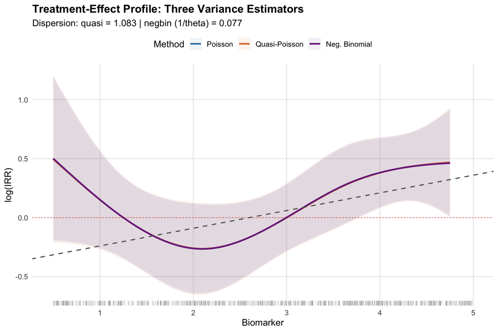

Three variance estimators: point estimates identical, CIs widen with overdispersion correction. Dashed line: true DGM interaction slope.

```r
t0 <- proc.time()[3]

prof_pois <- glm_effect_profile(
  df = df, outcome.name = "events", treat.name = "treat",
  z.name = "biomarker", effect_measure = "log_IRR",
  offset.name = "person_time", overdispersion = "none",
  spline_df = 3, z_by = 0.05, z_quantile = 0.95,
  alpha = 0.05, verbose = FALSE
)

prof_quasi <- glm_effect_profile(
  df = df, outcome.name = "events", treat.name = "treat",
  z.name = "biomarker", effect_measure = "log_IRR",
  offset.name = "person_time", overdispersion = "quasi",
  spline_df = 3, z_by = 0.05, z_quantile = 0.95,
  alpha = 0.05, verbose = FALSE
)

prof_nb <- glm_effect_profile(
  df = df, outcome.name = "events", treat.name = "treat",
  z.name = "biomarker", effect_measure = "log_IRR",
  offset.name = "person_time", overdispersion = "negbin",
  spline_df = 3, z_by = 0.05, z_quantile = 0.95,
  alpha = 0.05, verbose = FALSE
)

timings$profiles <- proc.time()[3] - t0

df_all <- rbind(
  data.frame(biomarker = prof_pois$z_profile, est = prof_pois$est,
             lower = prof_pois$lower, upper = prof_pois$upper,
             Method = "Poisson"),
  data.frame(biomarker = prof_quasi$z_profile, est = prof_quasi$est,
             lower = prof_quasi$lower, upper = prof_quasi$upper,
             Method = "Quasi-Poisson"),
  data.frame(biomarker = prof_nb$z_profile, est = prof_nb$est,
             lower = prof_nb$lower, upper = prof_nb$upper,
             Method = "Neg. Binomial")
)
df_all$Method <- factor(df_all$Method,
  levels = c("Poisson", "Quasi-Poisson", "Neg. Binomial"))

true_intercept <- 0.7 * 0.35 + (-0.4) * 0.65
true_slope <- 0.15

ggplot(df_all, aes(x = biomarker, y = est, colour = Method, fill = Method)) +
  geom_ribbon(aes(ymin = lower, ymax = upper), alpha = 0.08, colour = NA) +
  geom_line(linewidth = 1.0) +
  geom_abline(intercept = true_intercept - true_slope * 2.5,
              slope = true_slope,
              linetype = "dashed", color = "grey40", linewidth = 0.7) +
  geom_hline(yintercept = 0, linetype = "dotted", color = "red",
             linewidth = 0.4) +
  geom_rug(data = df, aes(x = biomarker, y = NULL),
           inherit.aes = FALSE,
           alpha = 0.1, sides = "b", length = unit(0.02, "npc")) +
  scale_colour_manual(values = c("Poisson" = "steelblue",
                                  "Quasi-Poisson" = "#E07B39",
                                  "Neg. Binomial" = "#7B2D8E")) +
  scale_fill_manual(values = c("Poisson" = "steelblue",
                                "Quasi-Poisson" = "#E07B39",
                                "Neg. Binomial" = "#7B2D8E")) +
  labs(x = "Biomarker", y = "log(IRR)",
       title = "Treatment-Effect Profile: Three Variance Estimators",
       subtitle = sprintf(
         "Dispersion: quasi = %.3f | negbin (1/theta) = %.3f",
         prof_quasi$dispersion, prof_nb$dispersion)) +
  theme_minimal(base_size = 12) +
  theme(legend.position = "top", panel.grid.minor = element_blank(),
        plot.title = element_text(face = "bold"))
```

```r
cat("=== Poisson ===\n")
```

```
#> === Poisson ===
```

```r
print(prof_pois)
```

```
#> GLM Effect Profile (poisson(log) / log_IRR)
#>   Profile points: 86
#>   Effect range: -0.264 to 0.496
#>   CI level: 95 %
```

```r
cat("\n=== Quasi-Poisson ===\n")
```

```
#>
#> === Quasi-Poisson ===
```

```r
print(prof_quasi)
```

```
#> GLM Effect Profile (quasipoisson(log) / log_IRR)
#>   Profile points: 86
#>   Effect range: -0.264 to 0.496
#>   Dispersion: 1.0827
#>   CI level: 95 %
```

```r
cat("\n=== Negative Binomial ===\n")
```

```
#>
#> === Negative Binomial ===
```

```r
print(prof_nb)
```

```
#> GLM Effect Profile (negative_binomial / log_IRR)
#>   Profile points: 86
#>   Effect range: -0.266 to 0.501
#>   Dispersion: 0.0766
#>   CI level: 95 %
```

# 11 Bootstrap Bias Correction

`forestsearch_bootstrap_dofuture()` resamples the data and re-runs the full pipeline to estimate selection bias in the post-hoc subgroup effect estimate.

```r
t0 <- proc.time()[3]

if (!is.null(fs$sg.harm) && length(fs$sg.harm) > 0) {
  fs_bc <- tryCatch(
    forestsearch_bootstrap_dofuture(
      fs,
      nb = sim_n_boot,
      parallel_args = list(plan = "sequential", workers = 1,
                           show_message = FALSE)
    ),
    error = function(e) {
      message("Bootstrap failed: ", e$message)
      NULL
    }
  )
} else {
  fs_bc <- NULL
  cat("No subgroup found --- bootstrap skipped\n")
}
```

```
#> No subgroup found --- bootstrap skipped
```

```r
timings$bootstrap <- proc.time()[3] - t0
```

```r
if (!is.null(fs_bc)) {
  cat("=== Bootstrap Summary ===\n")
  cat("Replicates:", sim_n_boot, "\n")

  bc_table <- tryCatch(
    format_bootstrap_table(fs_bc),
    error = function(e) {
      message("format_bootstrap_table(): ", e$message)
      NULL
    }
  )

  if (!is.null(bc_table)) {
    print(bc_table)
  }
}
```

# 12 Cross-Validation

K-fold cross-validation assesses replication stability: how often does the identified subgroup replicate across held-out folds?

```r
t0 <- proc.time()[3]

if (!is.null(fs$sg.harm) && length(fs$sg.harm) > 0) {
  fs_cv <- tryCatch(
    forestsearch_Kfold(
      fs,
      K = sim_n_cv_folds,
      parallel_args = list(plan = "sequential", workers = 1,
                           show_message = FALSE)
    ),
    error = function(e) {
      message("Kfold CV failed: ", e$message)
      NULL
    }
  )
} else {
  fs_cv <- NULL
  cat("No subgroup found --- CV skipped\n")
}
```

```
#> No subgroup found --- CV skipped
```

```r
timings$cv <- proc.time()[3] - t0
```

```r
if (!is.null(fs_cv)) {
  cat("=== Cross-Validation Summary ===\n")
  print(fs_cv)
}
```

# 13 Timing Summary

```r
timings$total <- (proc.time() - t_vignette_start)["elapsed"]

timing_df <- data.frame(
  Stage = c("GRF standalone", "forestsearch() pipeline",
            "Biomarker profiles", "Bootstrap", "Cross-validation",
            "Total"),
  Seconds = c(
    timings$grf_standalone, timings$forestsearch,
    timings$profiles, timings$bootstrap, timings$cv,
    timings$total
  ),
  stringsAsFactors = FALSE
)

gt(timing_df) |>
  tab_header(
    title = "Computational Timing",
    subtitle = sprintf("n = %d | %d bootstrap | %d CV folds | sequential",
                        n, sim_n_boot, sim_n_cv_folds)
  ) |>
  fmt_number(columns = Seconds, decimals = 1) |>
  cols_label(Stage = "Stage", Seconds = "Time (sec)") |>
  tab_style(
    style = cell_text(weight = "bold"),
    locations = cells_body(rows = Stage == "Total")
  )
```

Computational Timing

n = 800 | 50 bootstrap | 5 CV folds | sequential

| Stage | Time (sec) |
| --- | --- |
| GRF standalone | 0.1 |
| forestsearch() pipeline | 0.1 |
| Biomarker profiles | 0.0 |
| Bootstrap | 0.0 |
| Cross-validation | 0.0 |
| Total | 0.7 |

# 14 Summary

This document exercised the full ForestSearch v0.2.0 pipeline for count / rate outcomes: